# Final Project MSCI718

Yash Tiwari

08/04/2022

# ———–Section 1————-

Loading the required libraries

```r
library(foreign)
library(fastDummies)
library(glmnet)
```

```r
library(ggplot2)
```

```r
set.seed(100)
clinic_time <- 420 # minutes 9Am-4Pm
entries <-c() # storing total entries of customers-1000 entries
waiting_list <- c() # storing no of customers waiting- 1000 entries
average_wait <-c() # storing average waiting time of customers -1000 entries
office_close <-c() # office closing time - 1000 entries
```

The simulation has been run for 1000 times. However the first index of the above declared variables would yield the output for part a.

```r
for(x in 1:1000)
{
  entry_time <-rexp(100,rate = 0.1) # exponential distribution generation
  no_of_entry <- length(which(cumsum(entry_time)<=clinic_time)) # total number of customers/day
  d_time <-c(0,0,0) # waiting of doctors
  t = 0 # customer time at entry
  count_wait <- c()
  for(i in 1:no_of_entry)
  {
    t<- t+entry_time[i]
    t1 <- runif(1,5,20) # doctor's uniform distribution
    if(t>=d_time[1])
    {
      d_time[1] <- t1 + t
    }
    else if(t>=d_time[2])
    {
      d_time[2] <-t1 + t
    }
    else if(t >=d_time[3])
    {
      d_time[3] <- t1+t
    }
    else
    {
      k <- which(d_time==min(d_time)) # next available doctor
      temp <- d_time[k] - t # waiting time
      count_wait<-append(count_wait,temp) # appending waiting time to vector
      d_time[k] <- t+temp+t1

    }
  }
  avg <- sum(count_wait)/length(count_wait) # average waiting time
  if(is.na(avg)) # if no customers waited then avg = N.A
  {
    avg <- 0
  }
  entries<-append(entries,no_of_entry)
  waiting_list <-append(waiting_list,length(count_wait))
  average_wait <-append(average_wait,round(avg,3))
  if(clinic_time>max(d_time)) # store should close at least at 4pm
  {
    cl<- clinic_time
  }
  else
  {
    cl<- max(d_time)
  }
  office_close <- append(office_close,cl)
}
cl<- office_close[1]
xy <-0
if(cl  >clinic_time)
{
  xy <- as.integer(cl - clinic_time) # calculating minutes after 4 pm
}
print(paste("The total patients that came to office are",entries[1]))
```

```
## [1] "The total patients that came to office are 49"
```

```r
print(paste("Number of patients that waited for doctor are",waiting_list[1]))
```

```
## [1] "Number of patients that waited for doctor are 12"
```

```r
print(paste("The average waiting time is:",round(average_wait[1],2),"minutes"))
```

```
## [1] "The average waiting time is: 6.14 minutes"
```

```r
print(paste("The office closes at",4,":",xy,"PM"))
```

```
## [1] "The office closes at 4 : 15 PM"
```

Hence the results has been computed for part a

Results for part B

```r
k1<- sum(entries)/length(entries)
k2<- sum(waiting_list)/length(waiting_list)
k3<- sum(office_close)/length(office_close)
k4<- sum(average_wait)/length(average_wait)
xy <-0
if(k3  > clinic_time)
{
  xy <- as.integer(k3 - clinic_time)
}
print(paste("The Median of total patients that came to office are",as.integer(k1)))
```

```
## [1] "The Median of total patients that came to office are 42"
```

```r
print(paste("Median of Number of patients that waited for doctor are",as.integer(k2)))
```

```
## [1] "Median of Number of patients that waited for doctor are 6"
```

```r
print(paste("The Median of average waiting time is:",round(k4,2),"minutes"))
```

```
## [1] "The Median of average waiting time is: 3.98 minutes"
```

```r
print(paste("The office closes at",4,":0",xy,"PM"))
```

```
## [1] "The office closes at 4 :0 6 PM"
```

# —————— Section 2 ———————–

## Q1(A)

```r
#1.a.1
data_read<- read.dta("Q1Data1.dta")
#selecting 4 columns from the data-set
data1<-data.frame(state=data_read$state,marital=data_read$marital,
                  heat2 = data_read$heat2, heat4 = data_read$heat4)
#will be working on these 4 columns as described in S2.Q.1.a.1
#nrow(data1[!is.Na(data1$heat4),])
data2<- data1[!(data1$state=='hawaii' | data1$state =='washington dc' |
                  data1$state == 'alaska'),]
data2$state<-droplevels(data2$state)
```

removed the following states as described in the question

```r
#1.a.2
removal_index<-c() # storing indices that are to be removed
data2$heat2<-as.character(data2$heat2) #changing from factor to character
data2$heat4<-as.character(data2$heat4)
for( i in 1:nrow(data2))
{
  temp_heat2<-data2[i,3]
  temp_heat4<-data2[i,4]
  if(is.na(temp_heat2) && is.na(temp_heat4)) # checking if both are na
  {
    #data2<-data2[-i,]
    removal_index<-append(removal_index,i)
  }
  else if(is.na(temp_heat2) && !is.na(temp_heat4)) # checking if heat2 is na
  {
    data2[i,3]<-data2[i,4] # replacing heat 2 value with heat4
  }
}
data2<-data2[-removal_index,] #removing Na of heat 2
data2$heat2<-factor(data2$heat2)
data2$heat4<-factor(data2$heat4)
```

The heat2 column has 0 NA values

```r
#1.a.3 implementation
data3<-subset(data2,data2$heat2=="dem/lean dem" | data2$heat2 == "rep/lean rep")
data3$heat2<-droplevels(data3$heat2)
```

Stored only democratic and republic votes

```r
#Q1.1.4 implementation
data3$marital<-as.character(data3$marital)
removal_index1<-c()
for( i in 1:nrow(data3))
{
  if(is.na(data3[i,2]))
  {

    removal_index1<-append(removal_index1,i)
  }
  else if(data3[i,2] != "married")
  {
    data3[i,2] <- "other"
  }
}
data3<-data3[-removal_index1,]
data3$marital<-factor(data3$marital)
summary(data3$marital)
```

```
## married   other
##   13225    9042
```

marital column updated. 13225 married,9042 others and 1447 N.A values removed

## Q1(B)

```r
state_names <-sort(unique(data3$state))
l<-length(state_names)

#Creating empty data-frame to store all the results
result_1b<-data.frame(state=state_names,b1=rep(NA,l),b2=rep(NA,l),
                      b3=rep(NA,l),b4=rep(NA,l),b5=rep(NA,l))
for(i in 1:nrow(result_1b))
{
  temp1<- result_1b[i,1]
  #Q1.b.1
  democ_sp <-nrow(data3[data3$state==temp1 & data3$heat2 == "dem/lean dem",]) #selecting democratic voters/state
  no_of_candidates_state <- nrow(data3[data3$state==temp1,])
  result_1b[i,2]<-(democ_sp/no_of_candidates_state)*100
  #Q1.b.2
  married_people <- nrow(data3[data3$state==temp1 & data3$marital == "married",])
  result_1b[i,3] <- (married_people/no_of_candidates_state)*100
  #Q1.b.3
  married_democratic <- nrow(data3[data3$state==temp1 & data3$marital == "married"
                                   & data3$heat2 == "dem/lean dem",])
  result_1b[i,4] <- (married_democratic/married_people)*100
  #Q1.b.4
  non_married_democratic <-nrow(data3[data3$state==temp1 & data3$marital == "other"
                                      & data3$heat2 == "dem/lean dem",])
  result_1b[i,5] <- (non_married_democratic/(no_of_candidates_state-married_people))*100
  #Q1.b.5
  result_1b[i,6] <- result_1b[i,4] - result_1b[i,5]
}
#displaying 5 values
head(result_1b,n=5)
```

```
##        state       b1       b2       b3       b4        b5
## 1    alabama 34.88889 60.44444 25.73529 48.87640 -23.14111
## 2    arizona 46.76617 62.93532 36.36364 64.42953 -28.06589
## 3   arkansas 37.00441 65.63877 30.20134 50.00000 -19.79866
## 4 california 57.32452 54.93388 47.31481 69.52596 -22.21114
## 5   colorado 55.27778 58.61111 50.23697 62.41611 -12.17914
```

The following are the observations from the above analysis: Vermont has the highest percentage of democratic supporters and approx 74% of these votes are from non-married people. The survey also shows that most of the non-married people are inclined to vote for the democratic party

## Q1(C)

```r
Q1data2 <-read.csv("Q1Data2.csv",header = T)
# Q1.c.1
Q1data2_subset<-Q1data2[!(Q1data2$state=='Hawaii' | Q1data2$state =='District of Columbia' |
                            Q1data2$state == 'Alaska'),] # removing the selected states

#Q1.c.2
Q1data2_sub2<- subset(Q1data2_subset,select = c("state","vote_Obama_pct"))
head(Q1data2_sub2,n=5)
```

```
##        state vote_Obama_pct
## 1    Alabama           38.8
## 3    Arizona           45.0
## 4   Arkansas           38.8
## 5 California           60.9
## 6   Colorado           53.5
```

The above table shows the first five observations. The above analysis also shows that Vermont has voted the highest for Obama that is the democratic party. It’s value is very close to the survey conduced in the previous question data set.

## Q1(D)

### Assumption 1 - Complete Pooling

```r
#Creating dummy variable of the output and converting it to numeric type
#gm cannot run when output is a factor
y<-data3$heat2 # output
k<-dummy_cols(y,remove_first_dummy = T) # for accuracy calculation
y_numeric <-k$`.data_rep/lean rep`#for accuracy calculation

                      #Assumption 1 - Complete pooling
#Selecting only marital column to perform complete pooling on the states
x_1<-model.matrix(heat2~0+marital+state+marital*state,data=data3[-4]) # input to the model
penality_factor<- rep(1,ncol(x_1))
penality_factor[1] <- 0 # removing penalty for married:married column
penality_factor[2] <- 0 # removing penalty for married:other column
model_complete_pooling<-glmnet(x_1,y,alpha = 1,lambda = 10^5,family = "binomial",
                               penalty.factor = penality_factor)
coef(model_complete_pooling)
```

```
## 97 x 1 sparse Matrix of class "dgCMatrix"
##                                             s0
## (Intercept)                      -4.857757e-01
## maritalmarried                    7.346132e-01
## maritalother                      1.510858e-13
## statearizona                      .
## statearkansas                     .
## statecalifornia                   .
## statecolorado                     .
## stateconnecticut                  .
## statedelaware                     .
## stateflorida                      .
## stategeorgia                      .
## stateidaho                        .
## stateillinois                     .
## stateindiana                      .
## stateiowa                         .
## statekansas                       .
## statekentucky                     .
## statelouisiana                    .
## statemaine                        .
## statemaryland                     .
## statemassachusetts                .
## statemichigan                     .
## stateminnesota                    .
## statemississippi                  .
## statemissouri                     .
## statemontana                      .
## statenebraska                     .
## statenevada                       .
## statenew hampshire                .
## statenew jersey                   .
## statenew mexico                   .
## statenew york                     .
## statenorth carolina               .
## statenorth dakota                 .
## stateohio                         .
## stateoklahoma                     .
## stateoregon                       .
## statepennsylvania                 .
```

[output cut: 44 more lines]

```
## maritalother:stateoklahoma        .
## maritalother:stateoregon          .
## maritalother:statepennsylvania    .
## maritalother:staterhode island    .
## maritalother:statesouth carolina  .
## maritalother:statesouth dakota    .
## maritalother:statetennessee       .
## maritalother:statetexas           .
## maritalother:stateutah            .
## maritalother:statevermont         .
## maritalother:statevirginia        .
## maritalother:statewashington      .
## maritalother:statewest virginia   .
## maritalother:statewisconsin       .
## maritalother:statewyoming         .
```

```r
pred_prob_y<-predict(model_complete_pooling,type = "response",newx = x_1,s=0)
pred_y<- predict(model_complete_pooling,type = "class",newx = x_1,s=0)
complete_pooling_df <-data.frame(state_name = data3$state,actual_output = y,predicted = pred_y,
                                 prediction_prob = pred_prob_y)
names(complete_pooling_df)[3]<-paste("predicted_output")
names(complete_pooling_df)[4]<-paste("predicted_prob")
#Calculating accuracy
k<-dummy_cols(pred_y,remove_first_dummy = T)
y_numeric_pred1 <-k$`s1_rep/lean rep`

sum(abs(y_numeric - y_numeric_pred1))/length(y_numeric) #accuracy
```

```
## [1] 0.414874
```

Since the assumption is to to have no state level heterogeneity, all the state columns has been heavily penalized by setting very high values of lambda. Since the marital column are not to be penalized, their penalty factor has been set to zero. The model is only able to predict 2.3% of the variations in the data.

### Assumption 2 - No Pooling

```r
# Including states column as well
x_2 <-model.matrix(heat2~0+marital+state+state*marital,data = data3[-4])

model_no_pooling <-glmnet(x_2,y,lambda = 0,family = "binomial",alpha = 1)
pred_prob_y1<-predict(model_no_pooling,type = "response",newx = x_2,s=0)
pred_y1 <- predict(model_no_pooling,type = "class",newx = x_2,s=0)
no_pooling_df <-data.frame(state_name = data3$state,actual_output = y,predicted = pred_y1,
                           prediction_prob = pred_prob_y1,marital=data3$marital)
names(no_pooling_df)[3]<-paste("predicted_output")
names(no_pooling_df)[4]<-paste("predicted_prob")
coef(model_no_pooling)
```

```
## 97 x 1 sparse Matrix of class "dgCMatrix"
##                                             s0
## (Intercept)                       8.156191e-02
## maritalmarried                    8.670388e-01
## maritalother                      1.549580e-13
## statearizona                     -3.860829e-01
## statearkansas                    -1.079044e-01
## statecalifornia                  -8.382063e-01
## statecolorado                    -9.553281e-01
## stateconnecticut                 -1.128421e+00
## statedelaware                    -9.867752e-01
## stateflorida                     -5.450301e-01
## stategeorgia                     -3.988049e-01
## stateidaho                       -5.691448e-01
## stateillinois                    -1.068551e+00
## stateindiana                     -4.445799e-01
## stateiowa                        -8.291307e-01
## statekansas                      -6.811986e-01
## statekentucky                    -5.750826e-01
## statelouisiana                   -1.580804e-01
## statemaine                       -9.759042e-01
## statemaryland                    -1.455829e+00
## statemassachusetts               -1.072786e+00
## statemichigan                    -9.748330e-01
## stateminnesota                   -7.572374e-01
## statemississippi                 -3.261508e-01
## statemissouri                    -4.456890e-01
## statemontana                     -7.243515e-01
## statenebraska                    -5.341975e-01
## statenevada                      -7.843465e-01
## statenew hampshire               -7.769669e-01
## statenew jersey                  -9.789382e-01
## statenew mexico                  -1.006949e+00
## statenew york                    -1.346589e+00
## statenorth carolina              -6.089521e-01
## statenorth dakota                -8.011803e-01
## stateohio                        -6.254304e-01
## stateoklahoma                    -1.746156e-01
## stateoregon                      -7.952867e-01
## statepennsylvania                -9.366210e-01
```

[output cut: 44 more lines]

```
## maritalother:stateoklahoma       -8.609820e-02
## maritalother:stateoregon         -2.598242e-01
## maritalother:statepennsylvania    2.018367e-01
## maritalother:staterhode island   -4.498607e-02
## maritalother:statesouth carolina -3.059344e-02
## maritalother:statesouth dakota    2.940949e-01
## maritalother:statetennessee       3.529019e-02
## maritalother:statetexas           2.223522e-01
## maritalother:stateutah           -4.870985e-01
## maritalother:statevermont         4.819478e-01
## maritalother:statevirginia        1.317644e-01
## maritalother:statewashington      9.548403e-02
## maritalother:statewest virginia   2.453920e-01
## maritalother:statewisconsin       1.760456e-01
## maritalother:statewyoming         2.476097e+00
```

```r
#Calculating sum of squared error
k<-dummy_cols(pred_y1,remove_first_dummy = T)

y_numeric_pred1 <-k$`s1_rep/lean rep`
sum(abs(y_numeric - y_numeric_pred1))/length(y_numeric) #accuracy
```

```
## [1] 0.4015808
```

The above model has no pooling and all the states, marital and interaction between then are considered as predictors. It shows an negative relationship between the states and votes for almost all the states. The model is able to show 4.07% of variations in the data set. However, it might be subjected to over fitting.

### Assumption 3 - Partial Pooling

```r
penality_factor<- rep(1,ncol(x_2))
#making penalty factor of marital column = 0, since it should not be included
penality_factor[1] <- 0
penality_factor[2] <-0
set.seed(200)
model_min_lambda <- cv.glmnet(x_2,y,family = "binomial",type.measure = "class",
                              nfolds = 10,penality.factor=penality_factor)

min_lambda <- model_min_lambda$lambda.min
model_partial_pooling<- glmnet(x_2,y,family = "binomial",lambda = min_lambda)

pred_prob_y2<-predict(model_partial_pooling,type = "response",newx = x_2,
                      s=min_lambda)
pred_y2 <-predict(model_partial_pooling,type = "class",newx = x_2,
                  s=min_lambda)

partial_pooling_df <-data.frame(state_name = data3$state,actual_output = y,predicted = pred_y2,
                                prediction_prob = pred_prob_y2,marital=data3$marital)
names(partial_pooling_df)[3]<-paste("predicted_output")
names(partial_pooling_df)[4]<-paste("predicted_prob")
#Calculating sum of squared error
k<-dummy_cols(pred_y2,remove_first_dummy = T)
y_numeric_pred2 <-k$`s1_rep/lean rep`
sum(abs(y_numeric - y_numeric_pred2))/length(y_numeric)
```

```
## [1] 0.4061167
```

```r
coef(model_partial_pooling)
```

```
## 97 x 1 sparse Matrix of class "dgCMatrix"
##                                             s0
## (Intercept)                      -0.3711268636
## maritalmarried                    0.6582410377
## maritalother                     -0.0008595176
## statearizona                      .
## statearkansas                     0.2526545574
## statecalifornia                  -0.1391705000
## statecolorado                    -0.0572423792
## stateconnecticut                 -0.1880989202
## statedelaware                     .
## stateflorida                      .
## stategeorgia                      0.0240325979
## stateidaho                        .
## stateillinois                    -0.2042670235
## stateindiana                      .
## stateiowa                         .
## statekansas                       .
## statekentucky                     .
## statelouisiana                    0.2742987125
## statemaine                       -0.0632770708
## statemaryland                    -0.5919881720
## statemassachusetts               -0.2693537765
## statemichigan                    -0.2102519414
## stateminnesota                    .
## statemississippi                  .
## statemissouri                     0.0072604623
## statemontana                      .
## statenebraska                     .
## statenevada                       .
## statenew hampshire                .
## statenew jersey                  -0.1218396677
## statenew mexico                  -0.1247044005
## statenew york                    -0.4409205366
## statenorth carolina               .
## statenorth dakota                 .
## stateohio                         .
## stateoklahoma                     0.1853416242
## stateoregon                      -0.0251247666
## statepennsylvania                -0.1807738792
```

[output cut: 44 more lines]

```
## maritalother:stateoklahoma        .
## maritalother:stateoregon         -0.2347879731
## maritalother:statepennsylvania    .
## maritalother:staterhode island    .
## maritalother:statesouth carolina  .
## maritalother:statesouth dakota    .
## maritalother:statetennessee       .
## maritalother:statetexas           .
## maritalother:stateutah            .
## maritalother:statevermont         .
## maritalother:statevirginia        .
## maritalother:statewashington      .
## maritalother:statewest virginia   .
## maritalother:statewisconsin       .
## maritalother:statewyoming         0.5431390696
```

## Q1(E)

```r
pool_graph_df <-data.frame(state_name = state_names,obama_pct = Q1data2_subset$vote_Obama_pct,
                           actual_pct =result_1b$b1 ,
                           predicted_pct_no = rep(NA,l),
                           predicted_pct_partial = rep(NA,l),
                           predict_nopool_gap = rep(NA,l),
                            predict_partial_gap =rep(NA,l),
                           actual_gap = rep(NA,l)) # frame for graph
for(i in 1:l)
{
  t6 <- pool_graph_df[i,1] # state name
  t1<-nrow(partial_pooling_df[partial_pooling_df$state_name==t6 & partial_pooling_df$predicted_output == "dem/lean dem",])
  t2<-nrow(partial_pooling_df[partial_pooling_df$state_name==t6,])
  pool_graph_df[i,5]<- (t1/t2)*100 # partial predicted democratic voters /state
  t3 <-nrow(no_pooling_df[no_pooling_df$state_name==t6 & no_pooling_df$predicted_output == "dem/lean dem",])
  t4<- nrow(no_pooling_df[no_pooling_df$state_name==t6,])
  pool_graph_df[i,4] <- (t3/t4)*100 # no pool democratic voters/state
  t5<- nrow(partial_pooling_df[partial_pooling_df$state_name==t6 &
                                 partial_pooling_df$predicted_output == "dem/lean dem" &
                                 partial_pooling_df$marital=="married",])
  t7<-nrow(partial_pooling_df[partial_pooling_df$state_name==t6 &
                                partial_pooling_df$predicted_output == "dem/lean dem" &
                                partial_pooling_df$marital=="other",])
  pool_graph_df[i,7] <- abs(t5-t7)*100/t2 # partial marital gap/state
  t8 <- nrow(no_pooling_df[no_pooling_df$state_name==t6 &
                                  no_pooling_df$predicted_output == "dem/lean dem" &
                                  partial_pooling_df$marital=="married",])
  t9 <- nrow(no_pooling_df[no_pooling_df$state_name==t6 &
                             no_pooling_df$predicted_output == "dem/lean dem" &
                             partial_pooling_df$marital=="other",])
  pool_graph_df[i,6]<- abs(t8-t9)*100/t2 # no pool marital gap/state
  t10 <- nrow(data3[data3$state==t6 &
                              data3$heat2 == "dem/lean dem" &
                              data3$marital=="married",])
  t11 <- nrow(data3[data3$state==t6 &
                      data3$heat2 == "dem/lean dem" &
                      data3$marital=="other",])
  pool_graph_df[i,8] <- abs(t10-t11)*100/t2 # actual marital gap/state

}
```

The above code computes all the values required for plotting graphs for questions e,f,g. All the computations are stored in data frames which are being used to plot the graphs

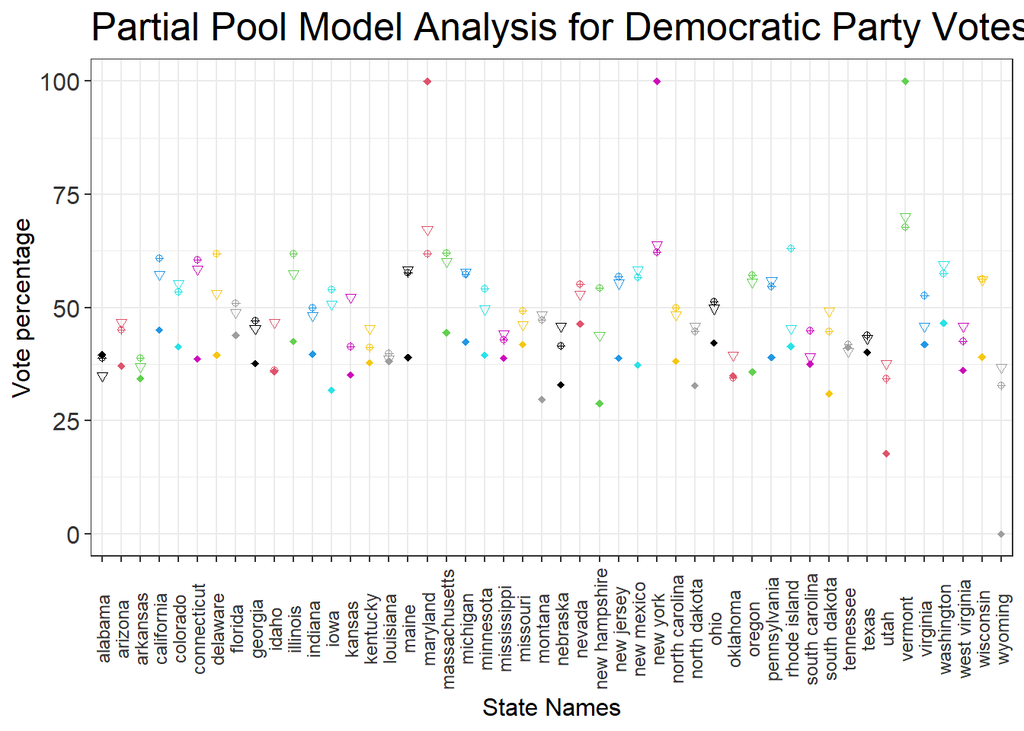

```r
ggplot(data = pool_graph_df)+
  geom_point(aes(x=state_name,y=actual_pct),shape = 25,color=1:48) + #triangle
  geom_point(aes(x=state_name,y=predicted_pct_partial),shape = 18,color=1:48)+ #diamond
  geom_point(aes(x=state_name,y=obama_pct),shape = 10,color=1:48) +#round
  labs(x= "State Names", y = "Vote percentage",title = "Partial Pool Model Analysis for Democratic Party Votes") +
  theme_bw() +
  theme(axis.text.x = element_text(colour = "grey20", size = 9, angle = 90, hjust = 0.5, vjust = 0.5),
        axis.text.y = element_text(colour = "grey20", size = 12),
        axis.title = element_text(size=12),
        strip.text = element_text(face = "italic"),
        text = element_text(size = 16))
```

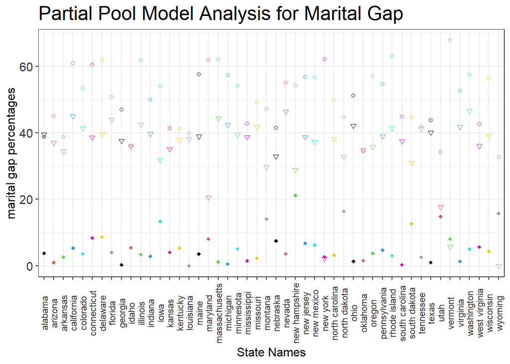

```r
ggplot(data = pool_graph_df)+
  geom_point(aes(x=state_name,y=predict_partial_gap),shape = 25,color=1:48) +#triangle shape
  geom_point(aes(x=state_name,y=actual_gap),shape = 18,color=1:48)+ #Diamond shape
  geom_point(aes(x=state_name,y=obama_pct),shape = 1,color=1:48) + #round shape
  labs(x= "State Names", y = "marital gap percentages",title = "Partial Pool Model Analysis for Marital Gap") +
  theme_bw() +
  theme(axis.text.x = element_text(colour = "grey20", size = 9, angle = 90, hjust = 0.5, vjust = 0.5),
        axis.text.y = element_text(colour = "grey20", size = 12),
        axis.title = element_text(size=12),
        strip.text = element_text(face = "italic"),
        text = element_text(size = 16))
```

The above graph shows the marital gap percentages amongst citizens who voted for democratic party. The marital gap is plotted in percentage for better visualization of the result. The model fails to accurately predict the marriage gap per state when compared to the actual values from the survey. From the prediction results it can be inferred that the lower the marriage gap, the more votes has been received by the democratic party from that state.

# Q1(G)

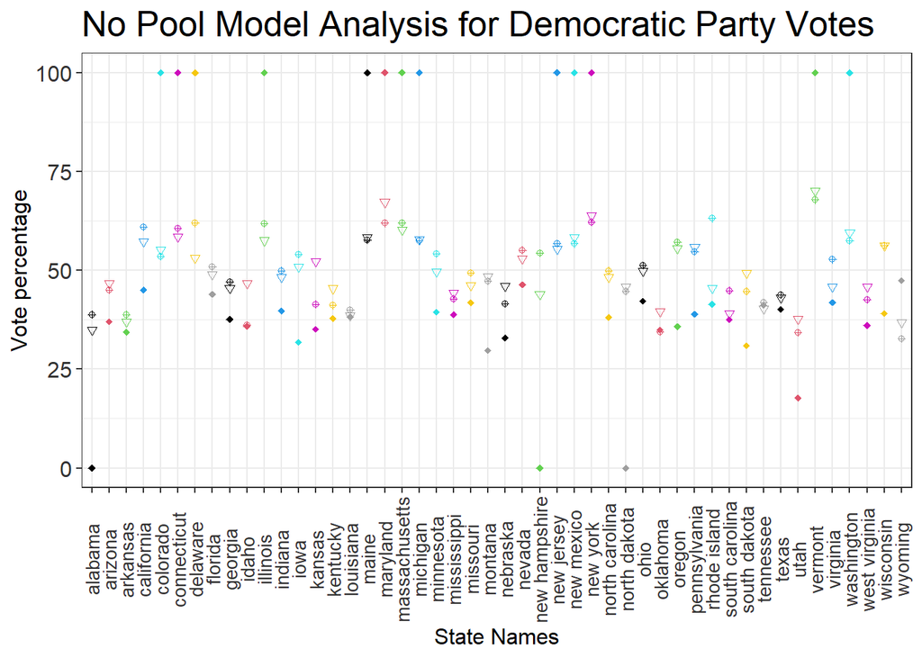

```r
#Marital gap for assumption 2
#All the computation done in part E
ggplot(data = pool_graph_df)+
  geom_point(aes(x=state_name,y=actual_pct),shape = 25,color=1:48) + #triangle
  geom_point(aes(x=state_name,y=predicted_pct_no),shape = 18,color=1:48)+#diamond
  geom_point(aes(x=state_name,y=obama_pct),shape = 10,color=1:48) +#round
  labs(x= "State Names", y = "Vote percentage",title = "No Pool Model Analysis for Democratic Party Votes") +
  theme_bw() +
  theme(axis.text.x = element_text(colour = "grey20", size = 10, angle = 90, hjust = 0.5, vjust = 0.5),
        axis.text.y = element_text(colour = "grey20", size = 12),
        strip.text = element_text(face = "italic"),
        axis.title = element_text(size=12),
        text = element_text(size = 16))
```

The above graph shows the voting percentage for democratic party using the no pooling predictions.The predictions have a lot of difference when compared to the actual survey results. Additionally, the partial pooling predictions perform better than the no pooling as the number of outliers are less in the partial pooling graph when compared to no pooling graph.

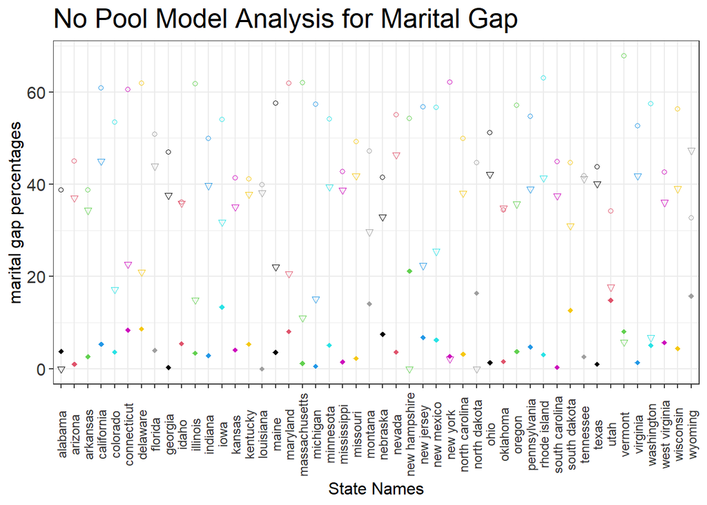

```r
ggplot(data = pool_graph_df)+
  geom_point(aes(x=state_name,y=predict_nopool_gap),shape = 25,color=1:48) + #triangle shape
  geom_point(aes(x=state_name,y=actual_gap),shape = 18,color=1:48)+ #Diamond shape
  geom_point(aes(x=state_name,y=obama_pct),shape = 1,color=1:48) + #round shape
  labs(x= "State Names", y = "marital gap percentages")+
  ggtitle("No Pool Model Analysis for Marital Gap")+
  theme_bw() +
  theme(axis.text.x = element_text(colour = "grey20", size = 9, angle = 90, hjust = 0.5, vjust = 0.5),
        axis.text.y = element_text(colour = "grey20", size = 12),
        strip.text = element_text(face = "italic"),
        axis.title = element_text(size=12),
        text = element_text(size = 16))
```